# Beaufort Lagoon source waters - poster

Christina Bonsell and Emily Bristol

Jan 18, 2020

### The Beaufort Lagoon Ecosystems Long-Term Ecological Research program (BLE LTER) samples lagoons and coastal areas across the Beaufort Sea coast

### We have 4 stations per lagoon system, two in shallow reaches of the lagoon (<1m), and two in deeper areas (>3m). We also sample major freshwater inflows associated with each lagoon.

### These lagoons exhibit large variability in **salinity** over the year.

(no data for EELD1)

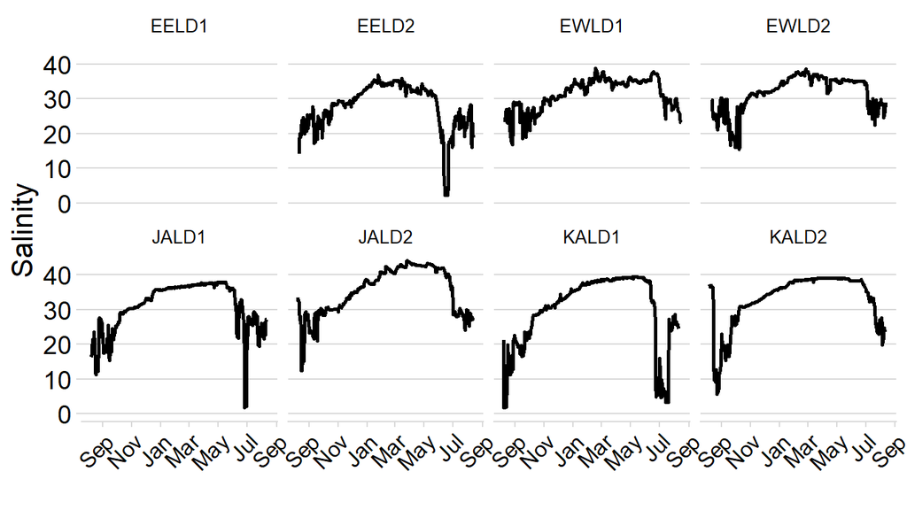

## What causes this?

### To find out, we used salinity and $\delta ^{18}O$ of lagoon waters sampled in April (full sea ice cover), June (sea ice break-up), and August (open water summer) to determine the relative contribution of sea ice melt (SIM), marine Polar Mixed Layer (PML), and meteoric water (MW) to these dynamic lagoons. Each of these endmembers has distinct salinity and $\delta ^{18}O$ values.

### $\delta ^{18}O$ of MW actually varies longitudinally, as seen by the pattern in freshwater inflow samples, here with stations ordered west->east:

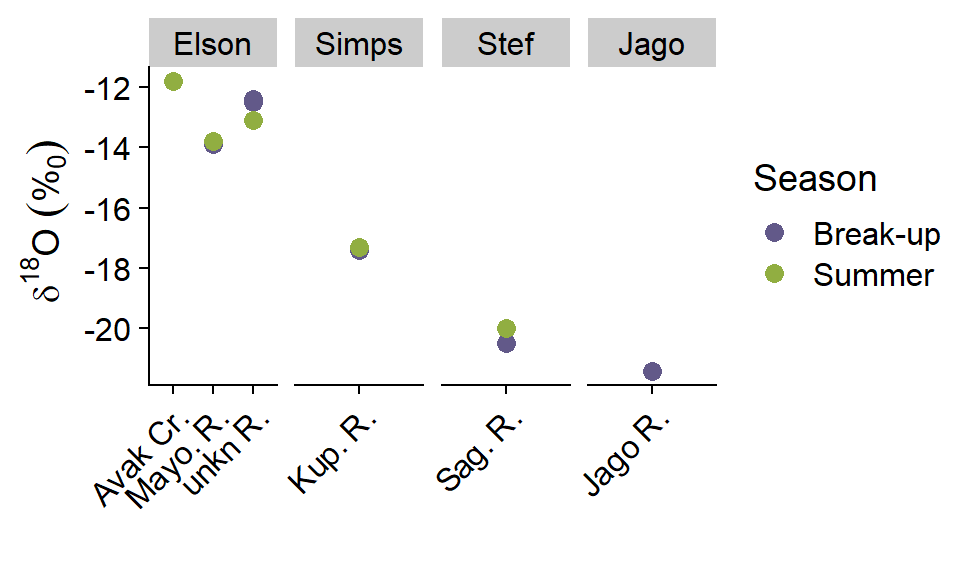

| Lagoon | riv_d18O | sd |
| --- | --- | --- |
| Elson | -12.92 | 0.83 |
| Simps | -17.35 | 0.07 |
| Stef | -20.25 | 0.35 |
| Jago | -21.40 | NaN |

### We solved the following system of equations for each lagoon water sample:

$SIM+MW+PML = 1$

$5*SIM + 0*MW + 32.1*PML = Salinity$

$-2*SIM + x*MW + -3.5*PML = \delta ^{18}O$

where $x$ is the value for rivers associated with a particular lagoon (see above table)

### At break-up, both SIM and MW usually contribute to the large drops in salinity, but it varies by lagoon system

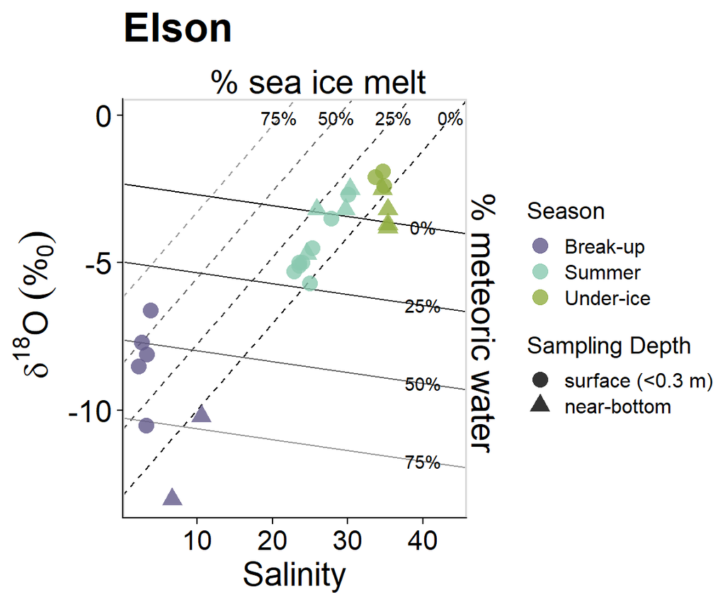

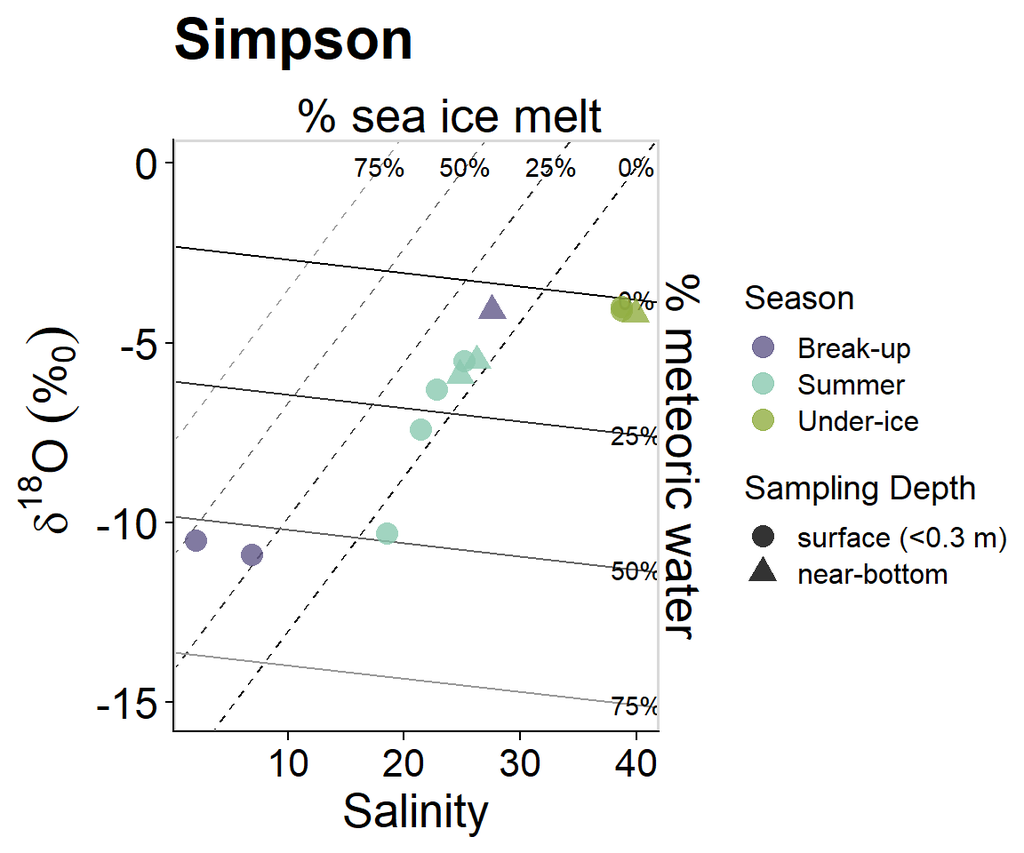

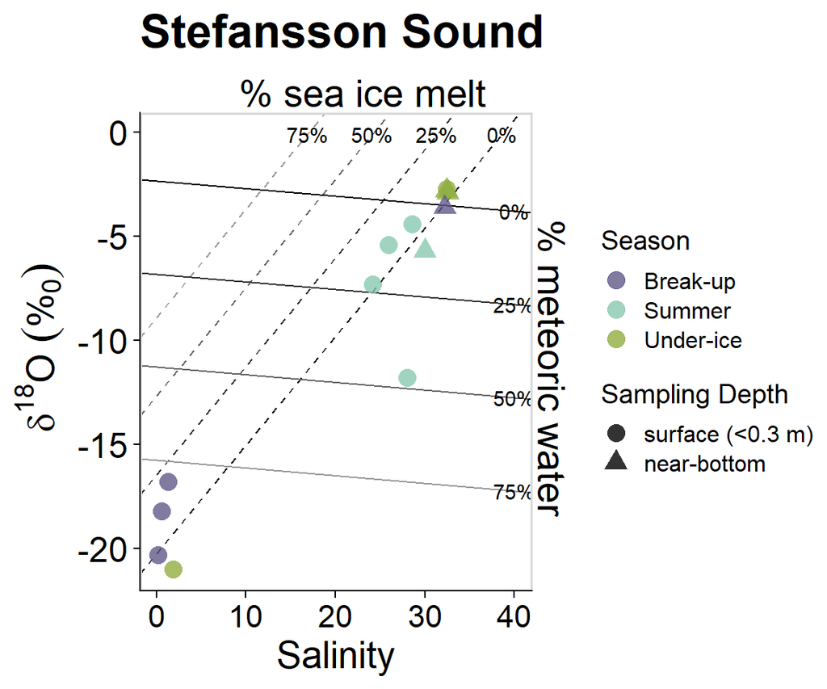

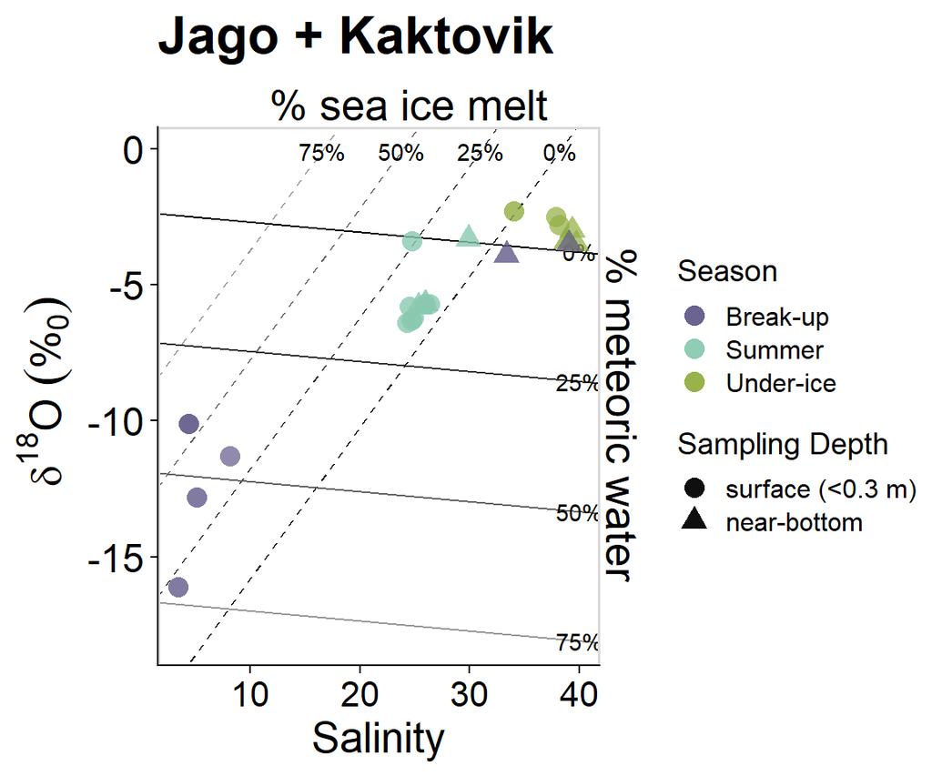

# Figures used in poster

plot mean by lagoon with error bar

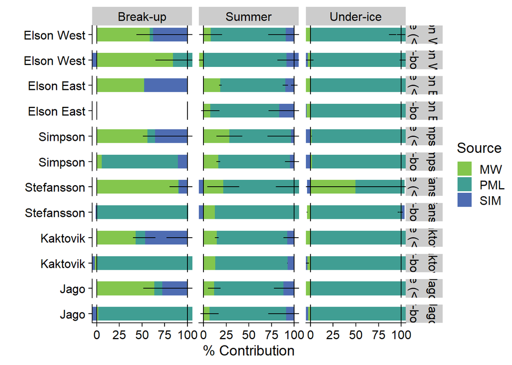

## Salinity data vs timepoints of sampling

### needs work

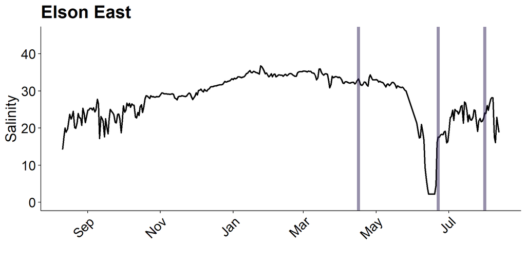

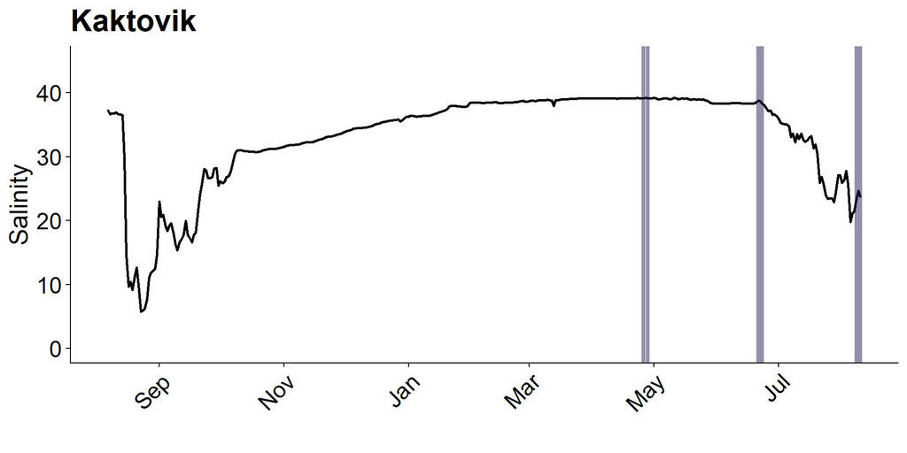

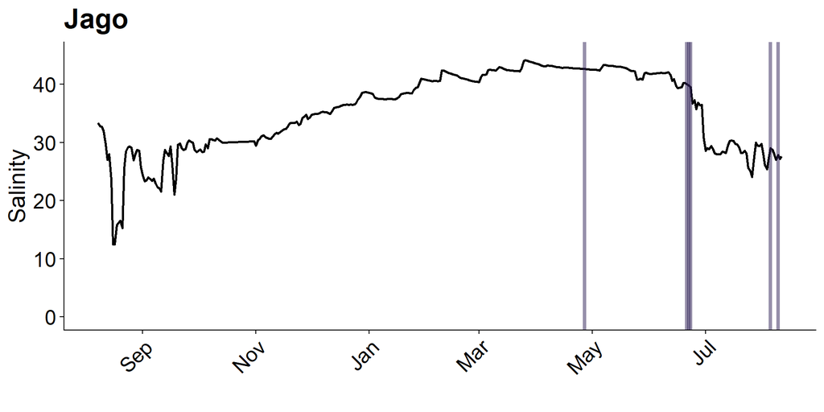

mixing plot

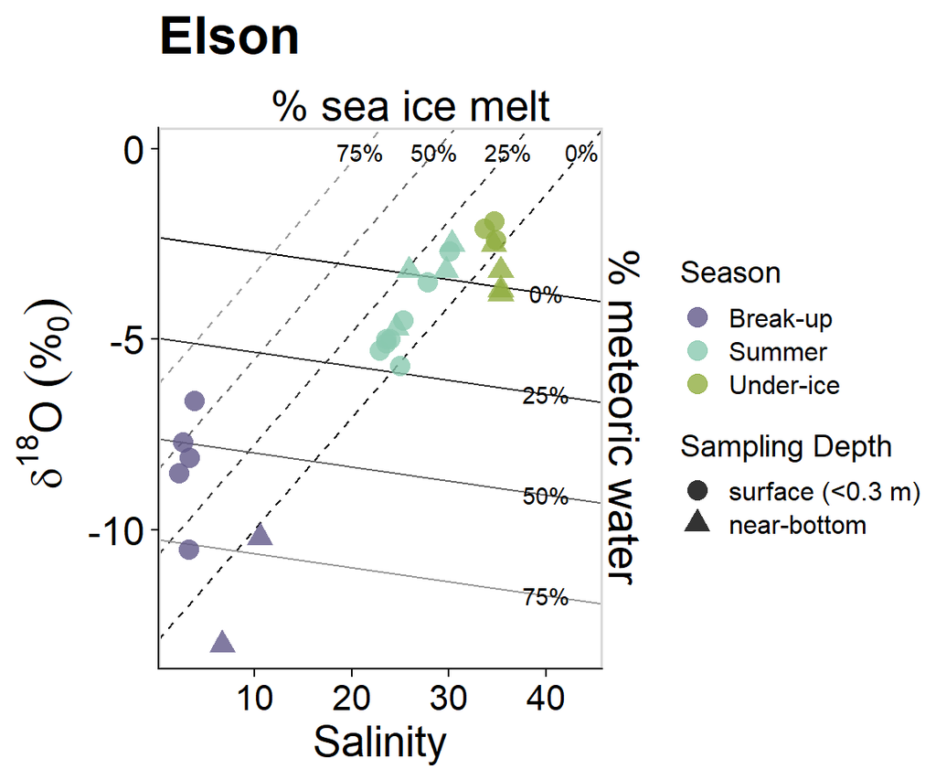

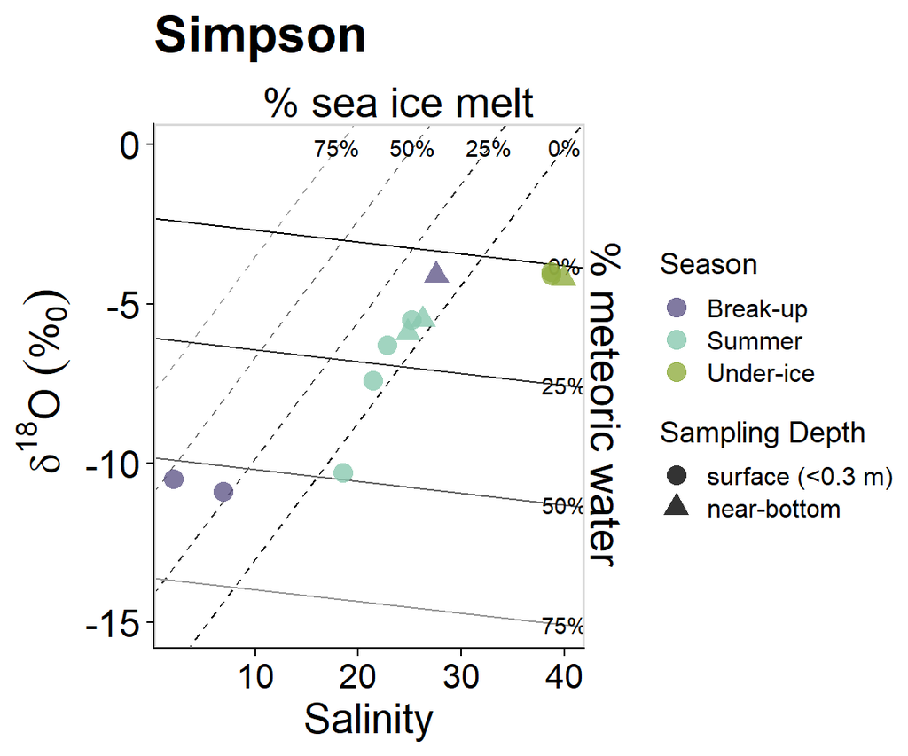

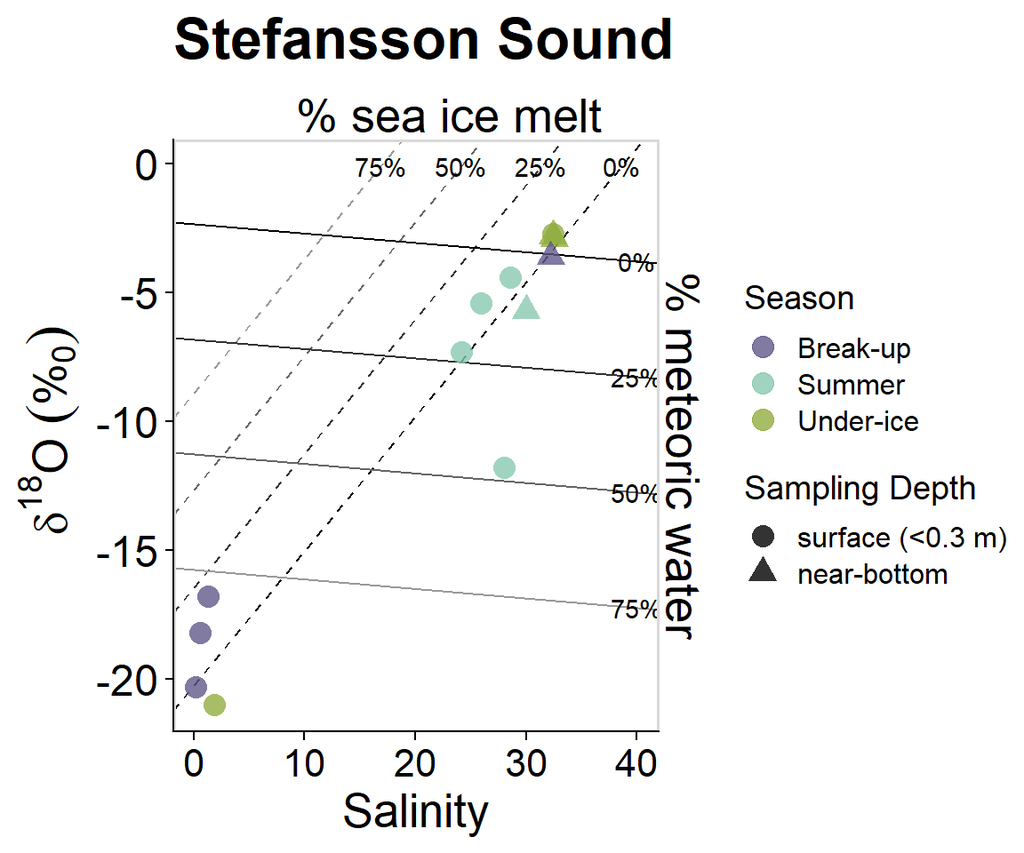

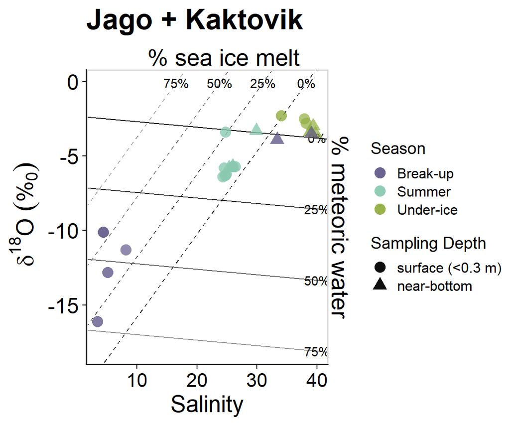